# Week 4 - Predicting Change

Team 1

2022-04-12

#### This lab is a data analysis that attempts to discover variables that may predict change concerning median home value and median home value growth. The variables we are using are from the US Census collection, using both 2000 and 2010 data. Looking at two different time periods allows us to analyze relationships between variables in the 2000 period and the subsequent change in home values in the following ten years.

## Part 1 - Data

| Statistic | Min | Pctl(25) | Median | Mean | Pctl(75) | Max |
| --- | --- | --- | --- | --- | --- | --- |
| MedianHomeValue2000 | 11,167 | 105,661 | 154,903 | 187,129 | 224,337 | 1,288,551 |
| MedianHomeValue2010 | 9,999 | 123,200 | 193,200 | 246,570 | 312,000 | 1,000,001 |
| MHV.Change.00.to.10 | -1,228,651 | 7,187 | 36,268 | 60,047 | 94,881 | 1,000,001 |
| MHV.Growth.00.to.12 | -97 | 6 | 25 | 33 | 50 | 6,059 |

### Dataframe Preview

#### Sample of dataset containing median home values in 2000 and 2010 and median home value change and growth. The change variables are calculated using the 2000 and 2010 times.

| MedianHomeValue2000 | MedianHomeValue2010 | MHV.Change.00.to.10 | MHV.Growth.00.to.12 |
| --- | --- | --- | --- |
| 98702.93 | 121500 | 22797.07 | 23.09665 |
| 93935.29 | 130500 | 36564.71 | 38.92542 |
| 102955.15 | 118700 | 15744.85 | 15.29293 |
| 115711.79 | 133500 | 17788.21 | 15.37286 |
| 150236.59 | 174500 | 24263.41 | 16.15013 |
| 90713.92 | 129600 | 38886.08 | 42.86672 |

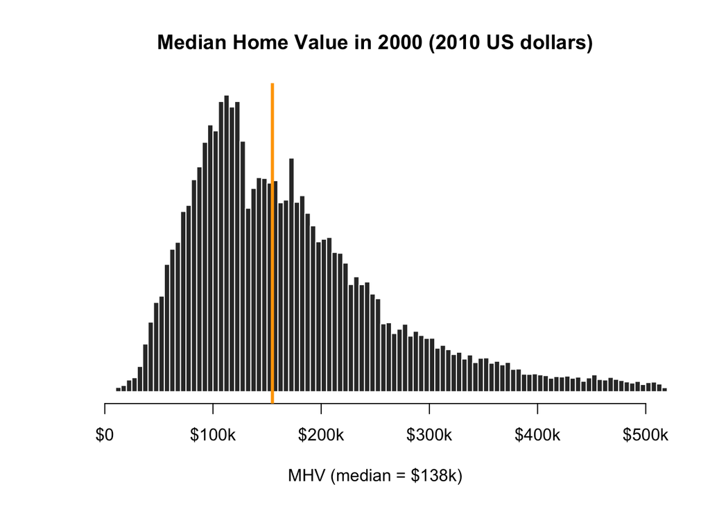

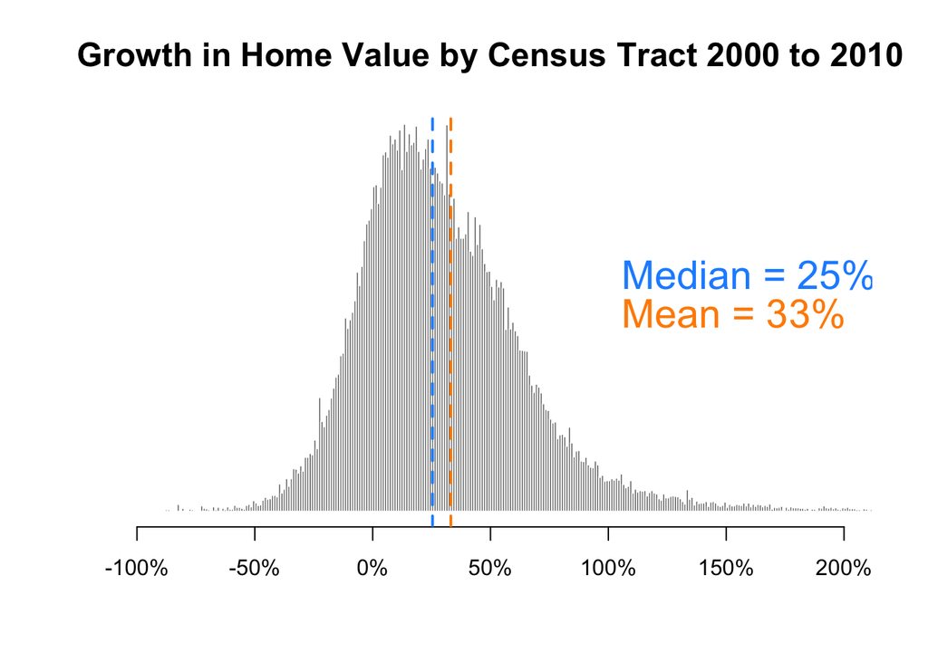

## Part 2 - Predicting MHV Change

#### For our data analysis, we chose to look at three variables that might be used to predict change in median home value change or growth: percent college graduates, percent black population, and percent unemployment.

#### To start, we will look at histogram data of the variables, raw and logged, to understand how the data is distributed in our dataset, which is looking at the tract level for unit analysis. We log the variables to normalize distribution of the data, in case it is skewed to the left or right, to better understand the relationship between our variables and our outcome, median home value change and median home value growth.

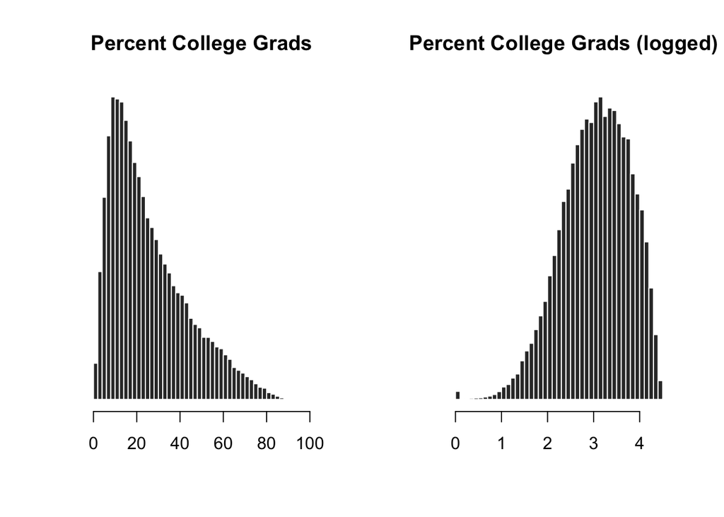

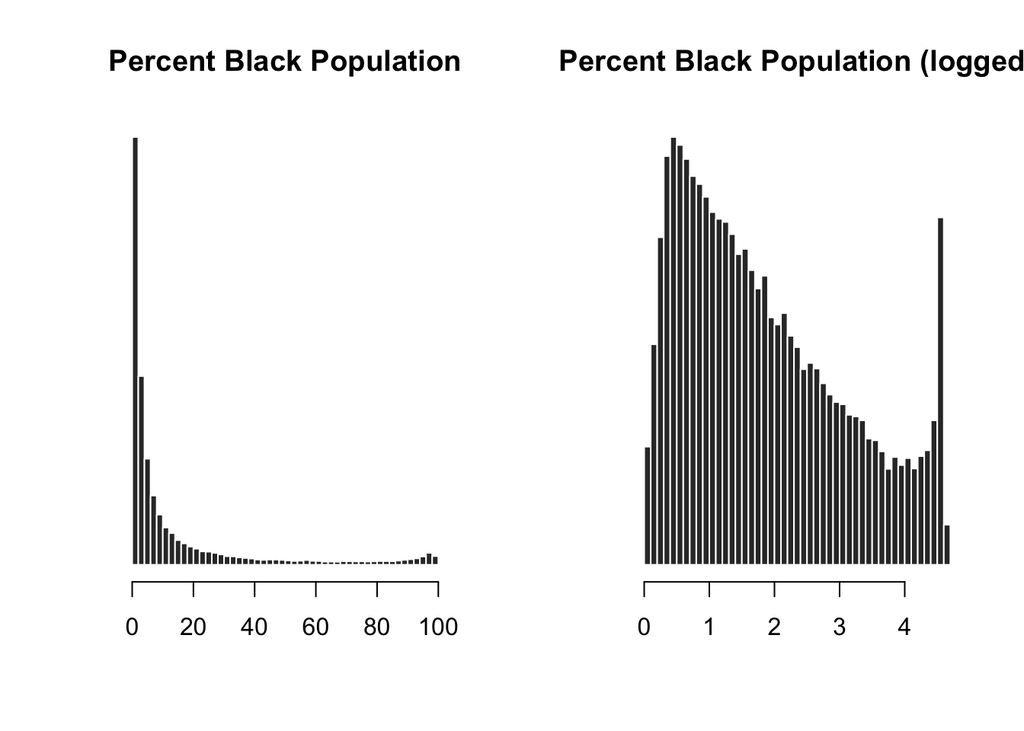

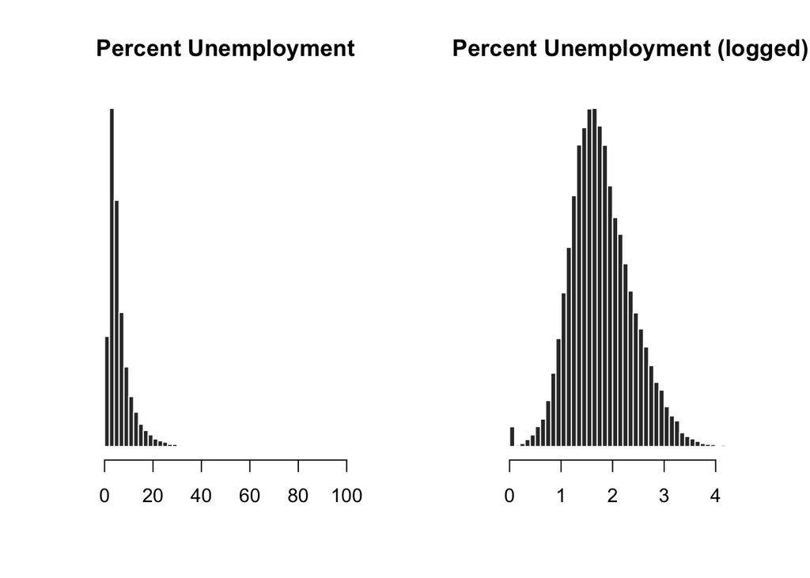

### Checking Skew

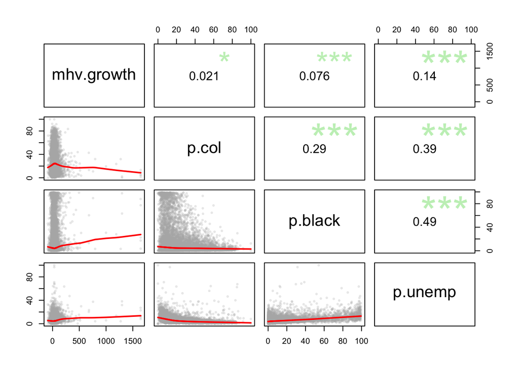

### Adjusting for skew

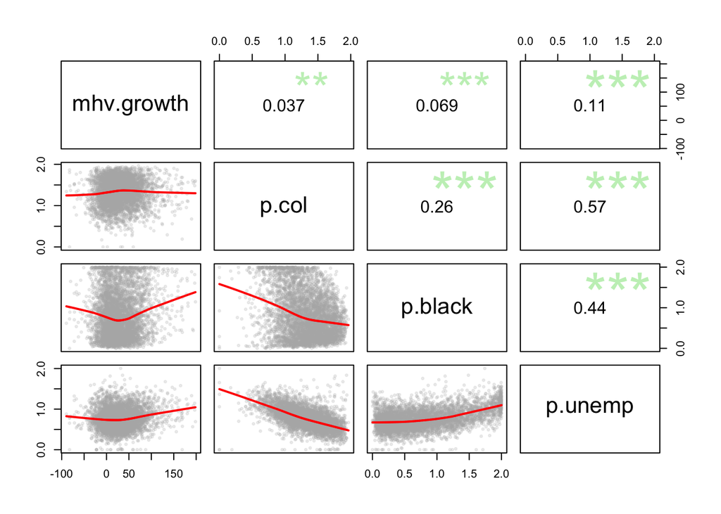

### Regression shows mutlicolinearity in coefficient and SD for percent Black population. Standard deviations increased for all variables but coefficents increased for percent college graduates and percent unemployed.

|  | *Dependent variable:* |  |  |  |
| --- | --- | --- | --- | --- |
|  | mhv.growth |  |  |  |
|  | (1) | (2) | (3) | (4) |
| p.black | 4.05*** |  |  | 1.16*** |
|  | (0.26) |  |  | (0.29) |
| p.col |  | 2.67*** |  | 15.19*** |
|  |  | (0.46) |  | (0.56) |
| p.unemp |  |  | 15.57*** | 25.33*** |
|  |  |  | (0.56) | (0.74) |
| Constant | 26.20*** | 25.92*** | 17.43*** | -11.16*** |
|  | (0.26) | (0.63) | (0.46) | (1.14) |
| Observations | 58,839 | 58,822 | 58,801 | 58,800 |
| Adjusted R<sup>2</sup> | 0.004 | 0.001 | 0.01 | 0.03 |
| Residual Std. Error | 35.10 (df = 58837) | 35.17 (df = 58820) | 34.94 (df = 58799) | 34.72 (df = 58796) |
| *Note:* | p<0.1; p<0.05; p<0.01 |  |  |  |